# Tuesday_25_5

MARIO

Helena

5/25/2021

## Loading the data

The simplest way is to use the ‘tt_load()’ function. This function accepts two types of inputs to determine which data to grab. It can be a date as a string in the YYYY-MM-DD format like below.

```r
data=tt_load("2021-05-25")
drivers = data$drivers
records = data$records
# alternatively tt_data <- tt_load(2019, week=3)

readme(data) # to understand the data set
```

## Some questions to explore

- How did the world records develop over time?
- Which track is the fastest?
- For which track did the world record improve the most?
- For how many tracks have shortcuts been discovered?
- When were shortcuts discovered?
- On which track does the shortcut save the most time?
- Which is the longest standing world record?
- Who is the player with the most world records?
- Who are recent players?

**My aim today is to explore some new ggplot themes**

- bbplot package: https://github.com/bbc/bbplot/
- tvthemes package: https://ryo-n7.github.io/2019-05-16-introducing-tvthemes-package/
- ggpomological : https://www.garrickadenbuie.com/project/ggpomological/

```r
#devtools::install_github("gadenbuie/ggpomological")
#devtools::install_github('bbc/bbplot')
#remotes::install_github("hrbrmstr/hrbrthemes")
#devtools::install_github("Ryo-N7/tvthemes")
```

### How did the records develop over time & bbplot

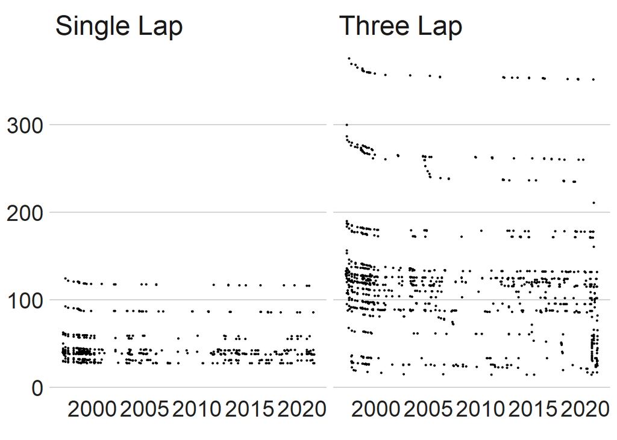

```r
# time_period (y), date (x), grid by type
records_over_time<-ggplot(aes(x=date, y=time), data=records)+
   geom_jitter(size=0.5)+
   facet_wrap(vars(type))+
   bbc_style()

records_over_time
```

```r
#bbplot::finalise_plot(plot_name = records_over_time,
#source = "Source: TidyTuesday",
#save_filepath = "21_05_25/images/records_over_time.png",
#width_pixels = 640,
#height_pixels = 550) # doesn't work
```

### Which track is the fastest?

```r
summary<-records %>% group_by(track, type) %>%
   summarise(mean=mean(time), min=min(time))

fastest_track<-summary %>%
   filter(min==min(summary$min))
fastest_average<-summary %>%
   filter(mean==min(summary$mean))
```

### For which track did the world record improve the most?

```r
summary_imp<-records%>%group_by(track, type)%>%
   summarise(min=min(time), max=max(time), dif=max-min,mean=mean(time), relative =dif/max )

max_improve <- summary_imp %>%
   filter(dif == max(summary_imp$dif))
max_rel_improve<-summary_imp %>%
   filter(relative==max(summary_imp$relative))
```

The highest absolute improvement was by 325.45 in the Rainbow Road, Three Lap. However the biggest relative improvement was in the Wario Stadium, Three Lap, this improvement was 265.75, which is 94.8 % of the original time.

```r
summary_shortcut<-records %>%
   group_by(track, shortcut)%>%
   summarise(n=n())
track_shortcut<-records %>%
   filter(shortcut == "Yes") %>%
   group_by(track) %>%
   summarise(n=n()) %>%
   nrow()

track_all<-records %>%
   group_by(track) %>%
   summarise(n=n()) %>%
   nrow()

track_list<-records%>%select(track)%>%
   unique()
```

Shortcut has been discovered on 12 out of 16 tracks.

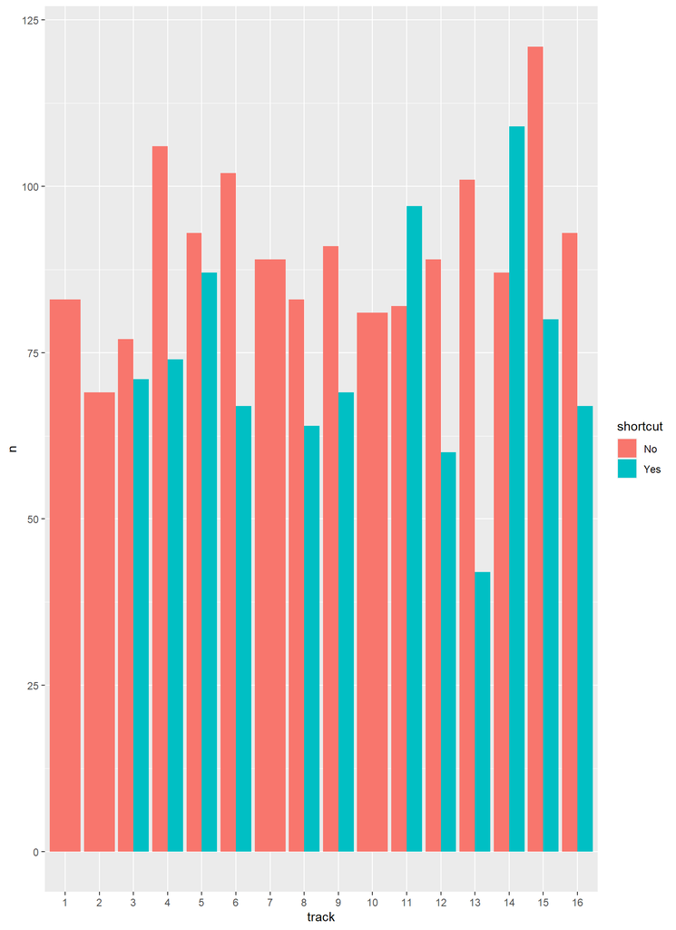

```r
ggplot(data=summary_shortcut, aes(x=track, y=n, fill=shortcut))+
   geom_col(position="dodge")+
     scale_x_discrete(labels = c(1:track_all))
```

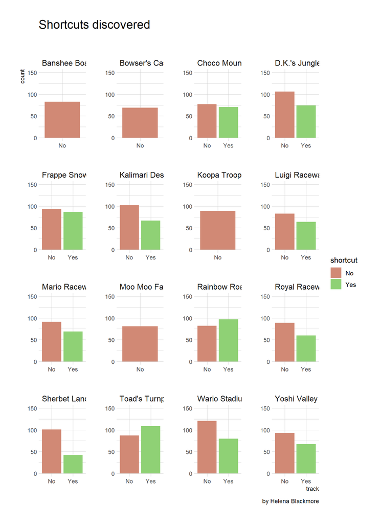

```r
ggplot(data=summary_shortcut, aes(x=shortcut, y=n, fill= shortcut))+
   geom_col(position="dodge")+
    labs(x="track", y="count",
       title="Shortcuts discovered",
       subtitle="",
       caption="by Helena Blackmore") +
   ylim(0,150)+
   theme_ipsum_ps()+
   facet_wrap(~track, scales="free")+
   scale_fill_ipsum()
```

```r
track_list%>% kable(align='l' )
```

| track |
| --- |
| Luigi Raceway |
| Moo Moo Farm |
| Koopa Troopa Beach |
| Kalimari Desert |
| Toad’s Turnpike |
| Frappe Snowland |
| Choco Mountain |
| Mario Raceway |
| Wario Stadium |
| Sherbet Land |
| Royal Raceway |
| Bowser’s Castle |
| D.K.’s Jungle Parkway |
| Yoshi Valley |
| Banshee Boardwalk |
| Rainbow Road |

### When were shortcuts discovered?

```r
records%>%
   group_by(track)%>%
   filter(shortcut=="Yes" & date==min(date))%>%
   select(track,date) %>%
  kableExtra::kable()
```

| track | date |
| --- | --- |
| Kalimari Desert | 1997-03-10 |
| Toad’s Turnpike | 1997-03-10 |
| Frappe Snowland | 1997-03-10 |
| Choco Mountain | 1997-03-10 |
| Mario Raceway | 1997-03-10 |
| Wario Stadium | 1997-03-10 |
| Sherbet Land | 1997-03-10 |
| Royal Raceway | 1997-03-10 |
| D.K.’s Jungle Parkway | 1997-03-10 |
| Yoshi Valley | 1997-03-07 |
| Rainbow Road | 1997-03-07 |

### On which track does the shortcut save the most time?

```r
# compare each track shortcut yes and shortcut no

shortcuts_dif<-records %>%
   group_by(track, shortcut, type)%>%
   filter(time==min(time))%>%
   select(track, type,shortcut,time)

time_saved <- function(track)
{
 a3 = shortcuts_dif%>%filter(track=="track", type=="Three Lap", shortcut=="Yes")
 a1 = shortcuts_dif%>%filter(track=="track", type=="Single Lap", shortcut=="Yes")

 b3 =shortcuts_dif%>%filter(track==track, type=="Three Lap", shortcut=="No")
 b1 =shortcuts_dif%>%filter(track==track, type=="Single Lap", shortcut=="No")

 c3=b3$time-a3$time
 c1=b1$time-a1$time
 print(c(c3,c1))
 return(c(c3,c1))
}

time_saved(track="Rainbow Road")

alltracks=unique(shortcuts_dif$track)

for track in alltracks {

}
```

[output not shown]

### Which is the longest standing world record?

```r
longest_record<-records%>%
   filter(record_duration==max(record_duration))

longest_player<-drivers %>%
   filter(player==longest_record$player, year==max(year)) %>%
   select(position, total, nation)%>%
   kable(col.names =c("current leader position","world records", "nation"),
         caption="More about the longest record holder",
         digits=2,
         align="c")%>%
   kable_styling(latex_options="striped",
                 full_width = FALSE,
                 position = "float_left"
                 )
```

The duration ofthe longest world record was 3659 days. Player Alex G completed the Yoshi Valley, Three Lap in 33.39 s on PAL on the 2010-11-27.

More about the longest record holder

| current leader position | world records | nation |
| --- | --- | --- |
| 42 | 4 | Germany |

### Who is the player with the most world records?

```r
library(tvthemes)
import_simpsons()         ## "Akbar" font
import_theLastAirbender() ## "Slayer" font
import_rickAndMorty()     ## "Get Schwifty" font
import_roboto_condensed() ## "Roboto Condensed" Google Font import from hrbrthemes
import_titillium_web()    ## "Titillium Web" Google Font import from hrbrthemes
import_spongeBob()        ## "Some Time Later" font
import_cinzel()           ## "Cinzel" font to use with 'The Palettes of Ice & Fire'

#install.packages("extrafont")
library(extrafont)
loadfonts() ## You need to do this at the beginning of a session.
```

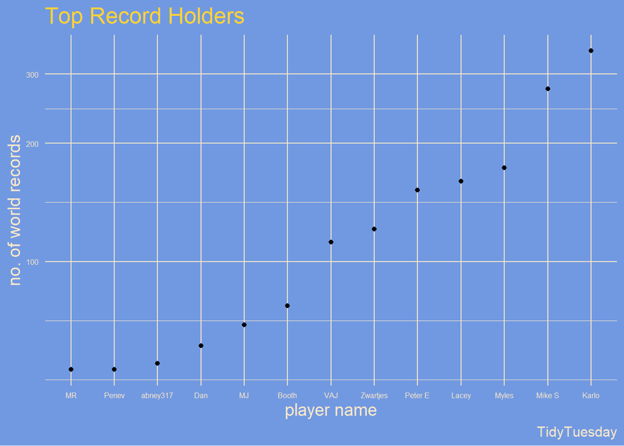

```r
most_records<-drivers%>%
   filter(total==max(total) & year==max(year))%>%
   select(position, total, nation)%>%
   kable(col.names =c("current leader position","world records", "nation"),
         caption="More about the holder of most world records",
         digits=2,
         align="c")%>%
   kable_styling(latex_options="striped",
                 full_width = FALSE,
                 position = "float_left"
                 )

top_drivers<-drivers%>%
   filter(total>=50 )%>%
   mutate(total = sort(total))

top_drivers%>%
  mutate(player = fct_reorder(player, total, .fun='median')) %>%
  ggplot( aes(x=reorder(player, total), y=total))+
   geom_point()+
   labs(title = "Top Record Holders",
       caption = glue::glue("
                      TidyTuesday"),
       x = "player name",
       y = "no. of world records") +
   theme_simpsons(title.font = "Akbar",
                 text.font = "Akbar",
                 axis.text.size = 6)+
   scale_y_continuous(trans='pseudo_log')
```

### Who are recent players?

```r
recent_players<-drivers%>%
   filter(year>= 2015)%>%
   group_by(player)%>%
   summarise(n=n())
```

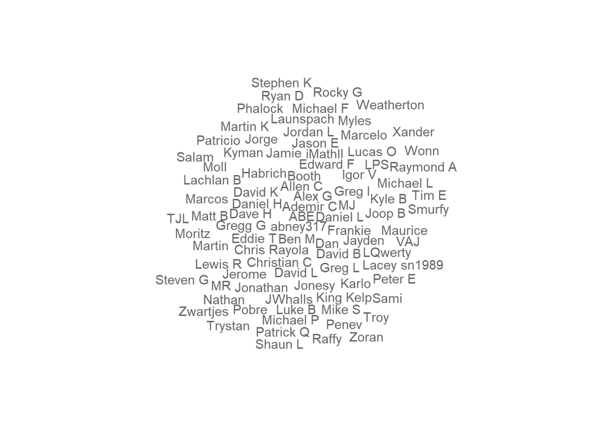

Players active since 2015

```r
set.seed(1234) # for reproducibility
wordcloud(words = recent_players$player, freq = recent_players$n, min.freq = 1,           max.words=200, random.order=FALSE, rot.per=0.0001,colors=brewer.pal(8, "Dark2"), scale=c(0.9,0.25))
```

```r
wordcloud2(data=recent_players, size=0.1, color='random-dark')
```

[interactive chart not shown]

Players active from 2015